# Reproducible Research Course Project 2

Introduction Storms and other severe weather events can cause both public health and economic problems for communities and municipalities. Many severe events can result in fatalities, injuries, and property damage, and preventing such outcomes to the extent possible is a key concern.

This project involves exploring the U.S. National Oceanic and Atmospheric Administration’s (NOAA) storm database. This database tracks characteristics of major storms and weather events in the United States, including when and where they occur, as well as estimates of any fatalities, injuries, and property damage.

# Data Download

Following code is used to read the data

```r
setwd("C:/Users/z003kkec/Desktop/Coursera/assignments/datasources")
storm_data <- read.csv("repdata_data_StormData.csv.bz2", header = TRUE, sep = ",")
```

# Data Processing

Across the United States, types of events that are most harmful with respect to population health

Total Fatalities

```r
library(dplyr)
fatalities <- storm_data %>% select(EVTYPE, FATALITIES) %>% group_by(EVTYPE) %>% summarise(tot.fatalities = sum(FATALITIES)) %>% arrange(desc(tot.fatalities))
head(fatalities,11)
```

```
## # A tibble: 11 x 2
##    EVTYPE         tot.fatalities
##    <fct>                   <dbl>
##  1 TORNADO                  5633
##  2 EXCESSIVE HEAT           1903
##  3 FLASH FLOOD               978
##  4 HEAT                      937
##  5 LIGHTNING                 816
##  6 TSTM WIND                 504
##  7 FLOOD                     470
##  8 RIP CURRENT               368
##  9 HIGH WIND                 248
## 10 AVALANCHE                 224
## 11 WINTER STORM              206
```

Total Injuries

```r
injuries <- storm_data %>% select(EVTYPE,INJURIES) %>% group_by(EVTYPE) %>% summarise(tot.injuries=sum(INJURIES)) %>% arrange(desc(tot.injuries))
head(injuries,11)
```

```
## # A tibble: 11 x 2
##    EVTYPE            tot.injuries
##    <fct>                    <dbl>
##  1 TORNADO                  91346
##  2 TSTM WIND                 6957
##  3 FLOOD                     6789
##  4 EXCESSIVE HEAT            6525
##  5 LIGHTNING                 5230
##  6 HEAT                      2100
##  7 ICE STORM                 1975
##  8 FLASH FLOOD               1777
##  9 THUNDERSTORM WIND         1488
## 10 HAIL                      1361
## 11 WINTER STORM              1321
```

Across the United States, types of events having greatest economic consequences.

```r
damage <- storm_data %>% select(EVTYPE,PROPDMG,PROPDMGEXP,CROPDMG,CROPDMGEXP)
Symbol <- sort(unique(as.character(damage$PROPDMGEXP)))
Multiplier <- c(0,0,0,1,10,10,10,10,10,10,10,10,10,10^9,10^2,10^2,10^3,10^6,10^6)
convert.Multiplier <- data.frame(Symbol, Multiplier)
damage$Prop.Multiplier <- convert.Multiplier$Multiplier[match(damage$PROPDMGEXP, convert.Multiplier$Symbol)]
damage$Crop.Multiplier <- convert.Multiplier$Multiplier[match(damage$CROPDMGEXP, convert.Multiplier$Symbol)]
damage <- damage %>% mutate(PROPDMG=PROPDMG*Prop.Multiplier) %>% mutate(CROPDMG=CROPDMG*Crop.Multiplier) %>% mutate(tot.damage =PROPDMG + CROPDMG )
damage.evtype <- damage %>% group_by(EVTYPE) %>% summarise(tot.propdamage = sum(tot.damage)) %>% arrange(desc(tot.propdamage))
head(damage.evtype,10)
```

```
## # A tibble: 10 x 2
##    EVTYPE            tot.propdamage
##    <fct>                      <dbl>
##  1 FLOOD               150319678250
##  2 HURRICANE/TYPHOON    71913712800
##  3 TORNADO              57352117607
##  4 STORM SURGE          43323541000
##  5 FLASH FLOOD          17562132111
##  6 DROUGHT              15018672000
##  7 HURRICANE            14610229010
##  8 RIVER FLOOD          10148404500
##  9 ICE STORM             8967041810
## 10 TROPICAL STORM        8382236550
```

# Plots

The top 10 events with the highest total fatalities and injuries are shown graphically.

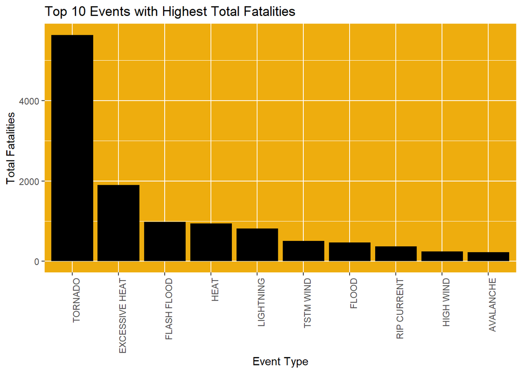

```r
library(ggplot2)
g <- ggplot(fatalities[1:10,],aes(x=reorder(EVTYPE,desc(tot.fatalities)),y=tot.fatalities)) +
  geom_bar(stat="identity",fill='black') +
  theme(panel.background = element_rect(fill = 'darkgoldenrod2'),axis.text.x = element_text(angle=90, vjust=1, hjust=1)) +
  labs(title="Top 10 Events with Highest Total Fatalities") +
  labs(x="Event Type",y="Total Fatalities")
print(g)
```

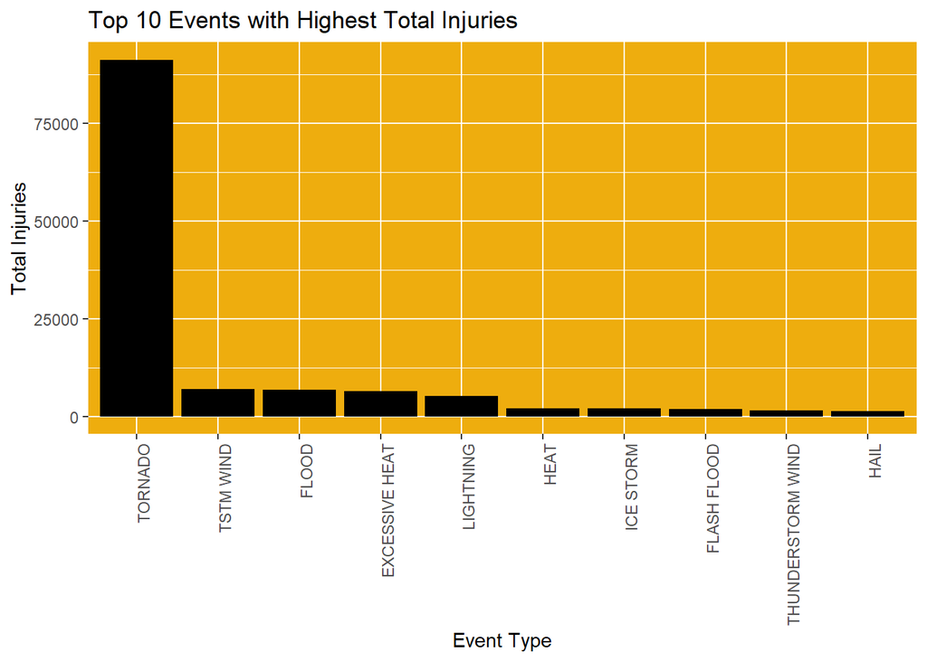

```r
g <- ggplot(injuries[1:10,],aes(x=reorder(EVTYPE,desc(tot.injuries)),y=tot.injuries)) +
  geom_bar(stat="identity",fill='black') +
  theme(panel.background = element_rect(fill = 'darkgoldenrod2'),axis.text.x = element_text(angle=90, vjust=1, hjust=1)) +
  labs(title="Top 10 Events with Highest Total Injuries") +
  labs(x="Event Type",y="Total Injuries")
print(g)
```

The top 10 events with the highest total economic damages (property and crop combined) are shown graphically.

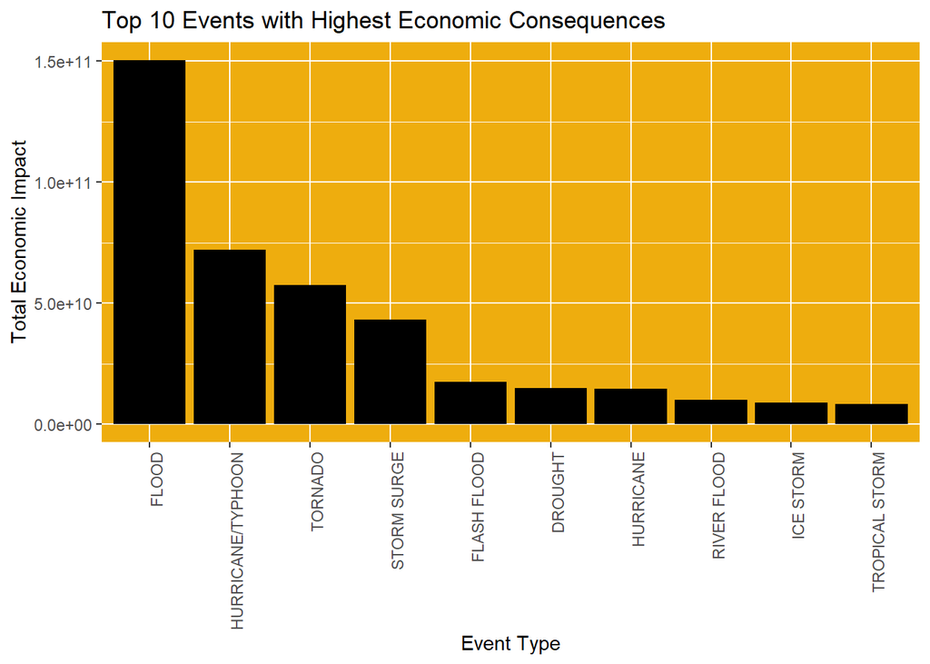

```r
g <- ggplot(damage.evtype[1:10,],aes(x=reorder(EVTYPE,desc(tot.propdamage)),y=tot.propdamage)) +
  geom_bar(stat="identity",fill='black') +
  theme(panel.background = element_rect(fill = 'darkgoldenrod2'),axis.text.x = element_text(angle=90, vjust=1, hjust=1)) +
  labs(title="Top 10 Events with Highest Economic Consequences") +
  labs(x="Event Type",y="Total Economic Impact")
print(g)
```